# Homework Week 1 Stat 593

### Neal Marquez

1. Suppose the force of mortality at age x for a cohort is $\mu(x) = x^2$. Denote by X the age at death of a person randomly chosen from this cohort (a random variable).

Subsections

```
a. Find the Cumulitive hazard function.
```

The cumulitive hazard function is $\Lambda(x) = \int_{0}^{x} \mu(u)du$. Given that our function is $\mu(x) = x^2$ we can take the integral and find that $\Lambda(x) = \frac{x^3}{3} - \frac{0}{3} = \frac{x^3}{3}$.

```
b. Find the survival function.
```

The survival function is defined as $S(x) = exp(- \Lambda (x))$ which makes it a function of the cumulitive hazard function. For our hazard function the survival function is $S(x) = exp(\frac{x^3}{-3})$.

```
c. Find and graph the probability density function of X.
```

The pdf can be found be taking the additive inverse of the derivative of the Survival function such the $f(x) = - \frac{d}{dx}S(x)$ which gives us $f(x) = exp(\frac{x^3}{-3}) ~ x^2$.

[figure not shown]

```
d. What is the name of this distribution?
```

Weibell distribution.

```
e. Find the life expectancy at birth of a member of this cohort.
```

Life expectancy at birth is given as $e_0 = E(X) = \int_{0}^{\infty} S(u)du$. this simplifies to $e_0 = \frac{\Gamma(\frac{1}{3})}{3^{(\frac{2}{3})}} \approx 1.2879$

```
f. Find the life expectancy at age 2 of a member of this cohort.
```

Life Expectancy at any age can be calculated using $e_x = \frac{\int_{x}^{\infty} S(u)du}{S(x)}$. For the case of life expectancy at age 2 we get $e_2 = \frac{\int_{2}^{\infty} S(u)du}{S(2)}$ which can be reduced to $e_2 = \frac{\Gamma(8/3, 1/3)}{3^{2/3} \times S(2)}$ and finally $e_2 \approx .2087$.

```
g. Find 2q2 for this cohort.
```

Given that $_nq_x = \frac{S(x) - S(x+n)}{S(x)}$ We can directly compute this as $\frac{exp(2^3/-3) - exp(4^3/-3)}{exp(2^3/-3)} \approx .9999$.

2. Estimating life tables.

Subsections

```
a. From the UN’s 2015 World Population Prospects, extract the estimates of
the age-specific mortality rates nmx for females in Mexico in 2005-2010.
Plot them against age on the raw and logarithmic scales, and comment on any
unusual features.
```

Below are the plots for age againts age specific mortality and log age specific mortality. It is odd that they are so smooth over age as if the data had some underlying funcional form.

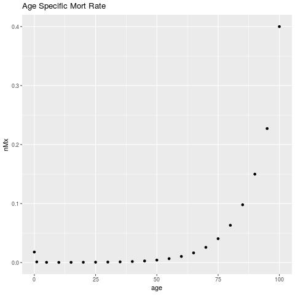

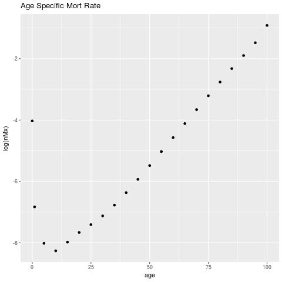

```
b. Using these, derive a life table for this population and time period.
Show your work.
```

Work is shown in accompanying code.

| age | nMx | nqx | npx | lx | ndx | nLx | Tx | ex |
| --- | --- | --- | --- | --- | --- | --- | --- | --- |
| 0 | 0.018 | 0.018 | 0.982 | 100000.00 | 1765.137 | 98764.40 | 7827612.83 | 78.276 |
| 1 | 0.001 | 0.004 | 0.996 | 98234.86 | 423.821 | 392091.81 | 7728848.43 | 78.677 |
| 5 | 0.000 | 0.002 | 0.998 | 97811.04 | 161.092 | 488652.48 | 7336756.62 | 75.009 |
| 10 | 0.000 | 0.001 | 0.999 | 97649.95 | 126.007 | 487934.73 | 6848104.14 | 70.129 |
| 15 | 0.000 | 0.002 | 0.998 | 97523.94 | 166.918 | 487202.42 | 6360169.41 | 65.216 |
| 20 | 0.000 | 0.002 | 0.998 | 97357.02 | 228.551 | 486213.74 | 5872966.99 | 60.324 |
| 25 | 0.001 | 0.003 | 0.997 | 97128.47 | 293.964 | 484907.45 | 5386753.25 | 55.460 |
| 30 | 0.001 | 0.004 | 0.996 | 96834.51 | 389.128 | 483199.72 | 4901845.80 | 50.621 |
| 35 | 0.001 | 0.006 | 0.994 | 96445.38 | 549.950 | 480852.03 | 4418646.07 | 45.815 |
| 40 | 0.002 | 0.009 | 0.991 | 95895.43 | 820.308 | 477426.38 | 3937794.04 | 41.063 |
| 45 | 0.003 | 0.013 | 0.987 | 95075.12 | 1252.741 | 472243.76 | 3460367.66 | 36.396 |
| 50 | 0.004 | 0.021 | 0.979 | 93822.38 | 1929.156 | 464289.02 | 2988123.90 | 31.849 |
| 55 | 0.007 | 0.032 | 0.968 | 91893.23 | 2962.095 | 452060.89 | 2523834.88 | 27.465 |
| 60 | 0.010 | 0.050 | 0.950 | 88931.13 | 4482.106 | 433450.39 | 2071774.00 | 23.296 |
| 65 | 0.016 | 0.078 | 0.922 | 84449.02 | 6619.208 | 405697.10 | 1638323.61 | 19.400 |
| 70 | 0.026 | 0.121 | 0.879 | 77829.82 | 9394.206 | 365663.57 | 1232626.51 | 15.837 |
| 75 | 0.040 | 0.183 | 0.817 | 68435.61 | 12522.000 | 310873.05 | 866962.94 | 12.668 |
| 80 | 0.063 | 0.271 | 0.729 | 55913.61 | 15142.485 | 241711.84 | 556089.89 | 9.946 |
| 85 | 0.098 | 0.387 | 0.613 | 40771.13 | 15782.650 | 164399.00 | 314378.05 | 7.711 |
| 90 | 0.150 | 0.527 | 0.473 | 24988.47 | 13177.349 | 91999.00 | 149979.05 | 6.002 |
| 95 | 0.227 | 0.679 | 0.321 | 11811.13 | 8017.496 | 39011.89 | 57980.04 | 4.909 |
| 100 | 0.400 | 1.000 | 0.000 | 3793.63 | 3793.630 | 18968.15 | 18968.15 | 5.000 |

```
c. Find the life expectancy at birth and at age 10 for this population.
```

Life expectancy at birth is $78.276$ while at age ten it is $70.129$.

## Appendix

```r
rm(list=ls())
pacman::p_load(pracma, data.table, wpp2015, ggplot2, knitr)

# data cleaning
data(mxF)
DF <- subset(as.data.table(mxF), country == "Mexico",
             select=c("age", "2005-2010"))
setnames(DF, c("age","nMx") )
str(DF)
DF[,age:=as.numeric(as.character(age))]

# plot the pdf
x <- seq(0, 10, .1)

fx <- function(x){
    exp(x**3 / -x) * x**2
}

jpeg('~/Documents/Classes/statdemog/week1/pdfX.jpg')
qplot(x, fx(x),geom = "line")
dev.off()

# hazard function
Hx <- function(x){
    (x^3) / (3)
}

# survival function
Sx <- function(x){
    exp(-Hx(x))
}

# life expectancy
e0 <- gamma(1/3) / 3^(2/3)
e0

# life expectancy at age 2
gammainc(8/3, 1/3)[["uppinc"]] / 3^(2/3) / Sx(2)

# 1g
(exp(2^3/-3) - exp(4^3/-3)) / exp(2^3/-3)

# 2a plot dat ain reg space and log space
jpeg('~/Documents/Classes/statdemog/week1/gomp.jpg')
ggplot(data=DF, aes(x=age, y=nMx)) + geom_point()
dev.off()

jpeg('~/Documents/Classes/statdemog/week1/loggomp.jpg')
ggplot(data=DF, aes(x=age, y=log(nMx))) + geom_point()
dev.off()

# Life Table code

DF[,n:=c(1,4, rep(5, nrow(DF) - 3), Inf)]
DF[,nqx:= 1-exp(-n * nMx)]
DF[age==max(age), nqx:=1]
DF[,npx:=1-nqx]
DF[,lx:=100000]
DF[,ndx:=lx*nqx]
for(i in 2:nrow(DF)){
    prevd <- DF[i-1,ndx]
    prevl <- DF[i-1,lx]
    DF[i, lx:= prevl - prevd]
    DF[,ndx:=lx*nqx]
}

DF[,nLx:=0]
currl <- DF[1,lx]
nextl <- DF[2,lx]
DF[1,nLx:=.3 * currl + .7 * nextl]
for(i in 2:(nrow(DF) - 1)){
    currl <- DF[i,lx]
    nextl <- DF[i+1,lx]
    DF[i, nLx:= n*.5*(nextl + currl)]
}

# pulled from ref table
DF[nrow(DF),nLx:=lx * 5]

DF[,Tx:=0]
fullnLx <- DF$nLx
for(i in 1:nrow(DF)){
    DF[i,Tx:=sum(fullnLx[i:nrow(DF)])]
}

DF[,ex:=Tx/lx]

kable(subset(DF, select=-n), format="markdown", digits = 3)
```